# report

Jason Su

August 9, 2018

# Probability practice

## Part A

$$\begin{align}
&P(RC)=0.3\\
&P(TC)=1-0.3=0.7\\
&P(Yes)=0.65\\
&P(No)=0.35\\
&P(Yes \ and \ RC)=P(Yes|RC) \times P(RC)=0.5*0.3=0.15\\
&P(No \ and \ RC)=P(RC)-P(Yes \ and \ RC)=0.3-0.15=0.15\\
&P(Yes|TC)=\frac{P(Yes \ and \ TC)}{P(TC)}=\frac{P(Yes)-P(Yes \ and \ RC)}{0.7}=\frac{0.65-0.15}{0.7}=0.714\\
\end{align}$$

## Part B

$$\begin{align}
&P(Pos|D)=0.993\\
&P(Neg|D')=0.9999\\
&P(Pos|D')=1-P(N|D')=0.0001\\
&P(D)=0.000025\\
&P(D')=1-P(D)=0.999975\\
&P(D|Pos)=\frac{P(D \ and \ Pos)}{P(Pos)}=\frac{P(D \ and \ Pos)}{P(D \ and \ Pos)+P(D' \ and \ Pos)}=\frac{P(Pos|D) \times P(D)}{P(Pos|D) \times P(D)+P(Pos|D') \times P(D')}=\frac{0.993 \times 0.000025}{0.993 \times 0.000025+0.0001 \times 0.999975}=0.1985\\
\end{align}$$

Problems in implementing a universal testing policy:

1. The probability of having the disease when getting positive result is actually not high. The result might cause unnecessary panic;
2. All assumed probabilities need to be very accurate which might be hard to achieve in reality.

# Exploratory analysis: green buildings

```r
library(ggplot2)
dat=read.csv("greenbuildings.csv")
```

## 1. Is it reasonable to remoeve low occupied outliers?

### *“I decided to remove these buildings from consideration, on the theory that these buildings might have something weird going on with them, and could potentially distort the analysis.”*

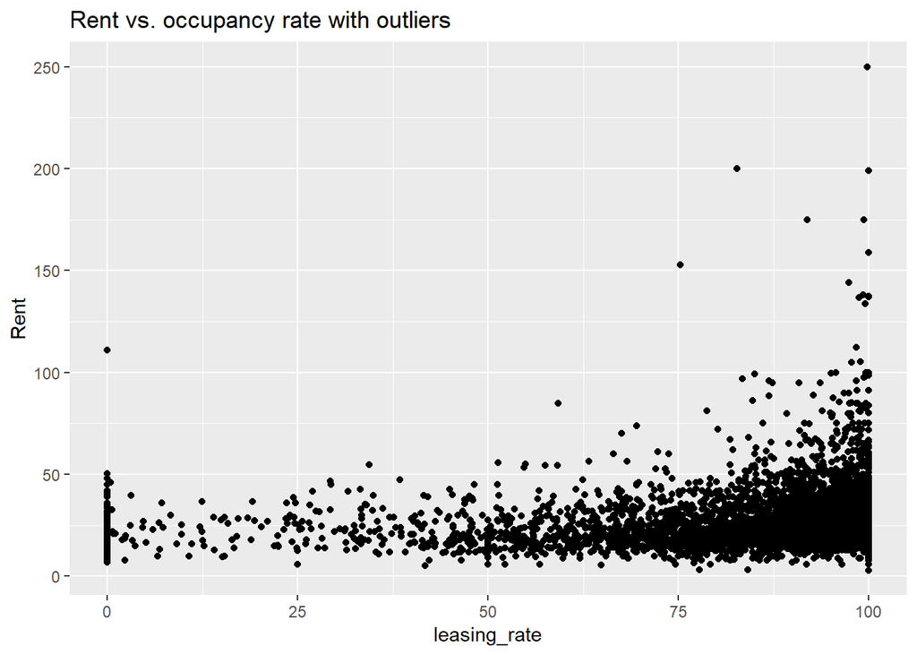

```r
par(mfrow=c(1,2))
greenbuilding = dat[,-c(12,13)]
greenbuilding$green_rating = factor(greenbuilding$green_rating)
greenbuilding$cluster = factor(greenbuilding$cluster)
ggplot(greenbuilding, aes(x=leasing_rate, y=Rent)) + geom_point()+ggtitle("Rent vs. occupancy rate with outliers")
```

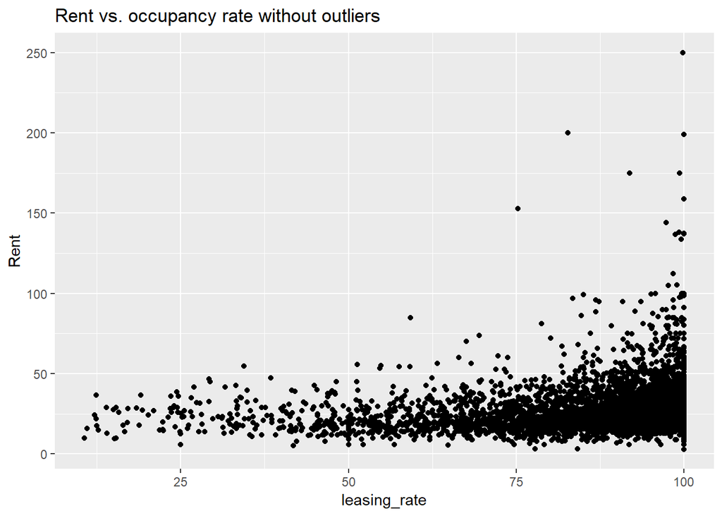

```r
mask = which(greenbuilding$leasing_rate > 10)
greenbuilding = greenbuilding[mask,]
ggplot(greenbuilding, aes(x=leasing_rate, y=Rent)) + geom_point()+ggtitle("Rent vs. occupancy rate without outliers")
```

### From the scatterplot we can see that there is a specific pattern when x is small. Therefore, it is correct to remove the outliers.

## 2. Should we use median or mean?

### *“I used the median rather than the mean, because there were still some outliers in the data, and the median is a lot more robust to outliers.”*

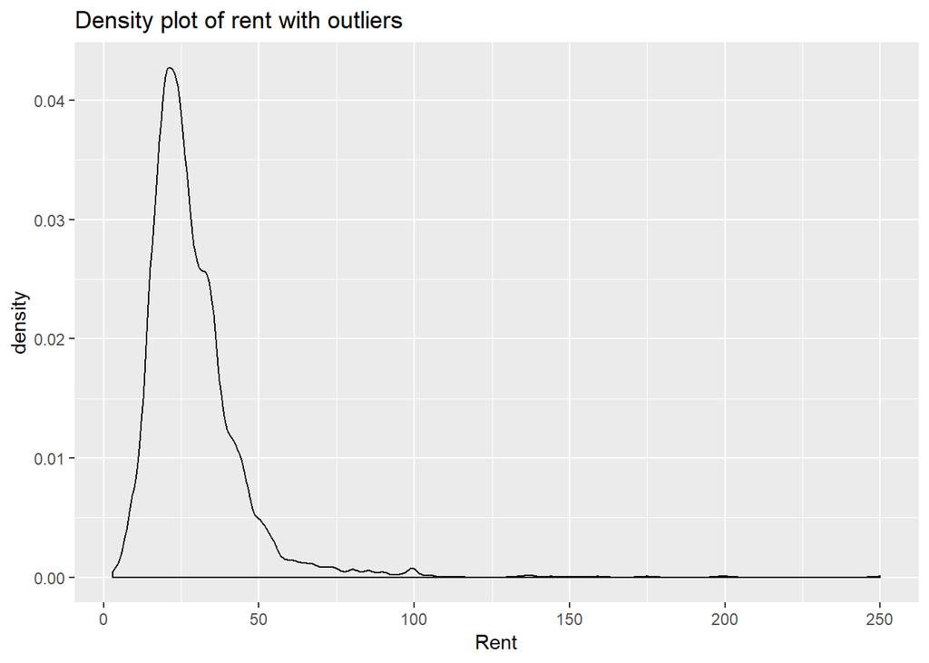

```r
ggplot(greenbuilding,aes(x=Rent))+geom_density()+ggtitle("Density plot of rent with outliers")
```

```r
mask2 = which(greenbuilding$Rent > 75)
paste("The number of outliers is",length(mask2))
```

```
## [1] "The number of outliers is 112"
```

```r
outliers = greenbuilding[mask2,]
remain = greenbuilding[-mask2,]
```

### We decided to use median or mean mainly based on the distribution and size of the dataset. From the first plot, we could see that the number of outliers is not small and the density plot is right-skewed. Therefore, it might be better to use median to measure the central tendency of the dataset. However, without the outliers the distribution of the dataset is quiet normally distributed which might be caused by its large size. So let’s try to dig into these outliers to check whether it is reasonable to remove them. We could also see that if we are able to remove them, the distribution is much more normally ditributed.

```r
library(gridExtra)

paste("The mean of rent of outliers is ",mean(outliers$Rent),", while the mean of rent of all buildings is ",mean(greenbuilding$Rent))
```

```
## [1] "The mean of rent of outliers is  103.209285714286 , while the mean of rent of all buildings is  28.5858458132569"
```

```r
paste("The mean of stories of outliers is ",mean(outliers$stories),", while the mean of stories of all buildings is ",mean(greenbuilding$stories))
```

```
## [1] "The mean of stories of outliers is  29.2946428571429 , while the mean of stories of all buildings is  13.8299257715848"
```

```r
paste("The number of green buildings among outliers is ",sum(outliers$green_rating=="1"),", while the number of outliers is ",dim(outliers)[1],". The fraction is ",sum(outliers$green_rating=="1")/dim(outliers)[1])
```

```
## [1] "The number of green buildings among outliers is  7 , while the number of outliers is  112 . The fraction is  0.0625"
```

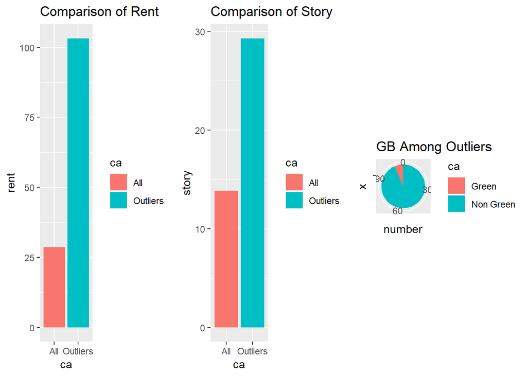

```r
rent_set = data.frame(ca=c("Outliers","All"),
                      rent=c(mean(outliers$Rent),mean(greenbuilding$Rent)))
p1=ggplot(data=rent_set,aes(x=ca,y=rent,fill=ca))+geom_bar(stat="identity")+ggtitle("Comparison of Rent")

story_set = data.frame(ca=c("Outliers","All"),
                      story=c(mean(outliers$stories),mean(greenbuilding$stories)))
p2=ggplot(data=story_set,aes(x=ca,y=story,fill=ca))+geom_bar(stat="identity")+ggtitle("Comparison of Story")

number_set = data.frame(ca=c("Green","Non Green"),
                      number=c(sum(outliers$green_rating=="1"),dim(outliers)[1]-sum(outliers$green_rating=="1")))
p3=ggplot(number_set,aes(x="",y=number,fill=ca))+geom_bar(width = 1, stat = "identity")+coord_polar("y", start=0)+ggtitle("GB Among Outliers")

grid.arrange(p1,p2,p3, ncol=3)
```

### From the graphs, we can see that first, most of these outliers have significantly higher rent than the average level. And then most of them have specifically high stories level which might be the reason of extremely high rent. Considering we are estimating for a 15-story building. These outliers might be less valuable for analysis. In addition, among these outliers, there exist few green buildings, which means we are not able to compare green and non-green building among these outleirs.In conclusion, we might not miss insight even if we remove these outliers.

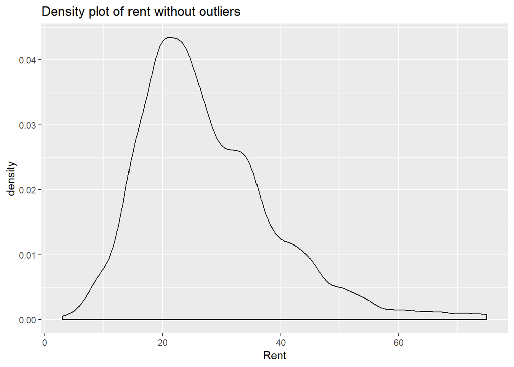

```r
ggplot(remain,aes(x=Rent))+geom_density()+ggtitle("Density plot of rent without outliers")
```

## 3. Should we just compare the mean rent of buildings from all areas?

### *“The median market rent in the non-green buildings was $25 per square foot per year, while the median market rent in the green buildings was $27.60 per square foot per year”*

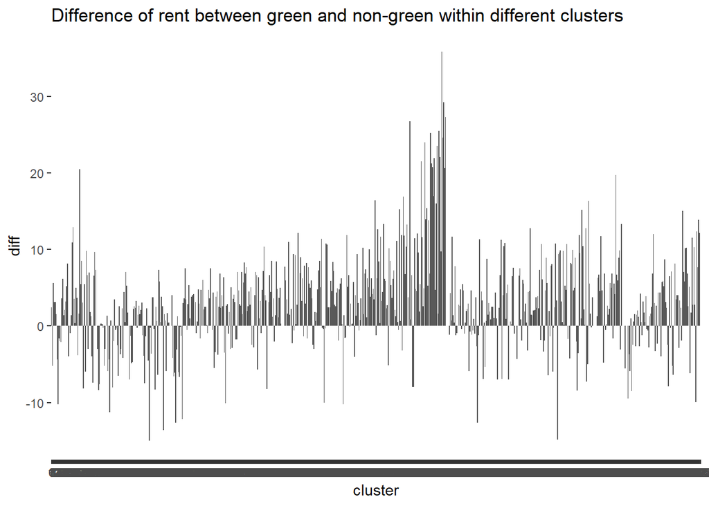

```r
library(dplyr)

mean_rent_green = remain %>% group_by(cluster) %>%
  summarise(diff=mean(Rent[green_rating==1])-mean(Rent[green_rating==0]))

ggplot(data=mean_rent_green, aes(x=cluster, y=diff)) +
  geom_bar(stat="identity",position=position_dodge())+ggtitle("Difference of rent between green and non-green within different clusters")
```

## 4. Future Estimation

### *“The median market rent in the non-green buildings was $25 per square foot per year, while the median market rent in the green buildings was $27.60 per square foot per year: about $2.60 more per square foot.”*

### Instead of revenue, we might be more interested in the future profit, which means we should also consider about the cost and the occupancy rate.

```r
remain["profit"]=remain["Rent"]-remain["Gas_Costs"]-remain["Electricity_Costs"]
remain=remain[,-c(19,20)]

profit_set = remain %>% group_by(green_rating) %>% summarise(mean_profit=mean(profit),mean_occupied=mean(leasing_rate))
p1=ggplot(data=profit_set,aes(x=green_rating,y=mean_profit,fill=green_rating))+geom_bar(stat="identity")+ggtitle("Comparison of mean rent")
p2=ggplot(data=profit_set,aes(x=green_rating,y=mean_occupied,fill=green_rating))+geom_bar(stat="identity")+ggtitle("Comparison of occupied rate")
profit_set
```

```
## # A tibble: 2 x 3
##   green_rating mean_profit mean_occupied
##   <fct>              <dbl>         <dbl>
## 1 0                   27.3          84.3
## 2 1                   29.3          89.3
```

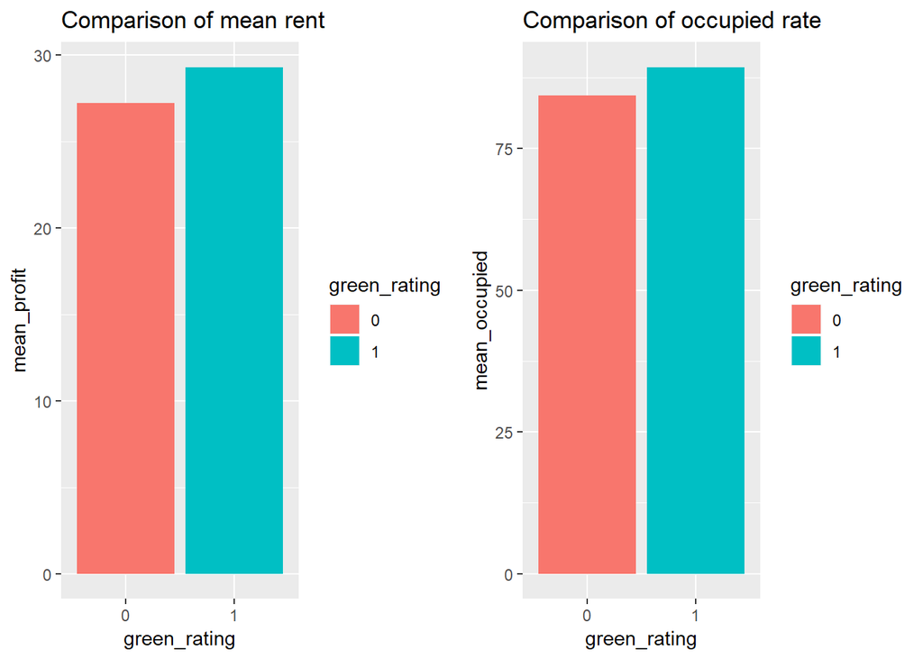

```r
grid.arrange(p1,p2, ncol=2)
```

### Based on the results above, a normal building might gain an additional

### $250000*(29.3163*0.8935 - 27.2548*0.8429) = 805261$ dollars of extra revenue per year if we buil the green building.

### Therefore, we might be able to recuperate the extra $5 million cost in around 6.2 years. Since the building will be able to earn rents for more than 30 years, “going green” is probably a good investment.

# Bootstrapping

## Setting up the dataset including these five ETFs from 2007-01-01

```r
library(mosaic)
library(quantmod)
library(foreach)

#Import the needed stocks data from 2007-01-01
stocks_list = c("SPY","TLT","LQD","EEM","VNQ")
getSymbols(stocks_list,from="2007-01-01")
```

```
## [1] "SPY" "TLT" "LQD" "EEM" "VNQ"
```

```r
SPYa = adjustOHLC(SPY)
TLTa = adjustOHLC(TLT)
LQDa = adjustOHLC(LQD)
EEMa = adjustOHLC(EEM)
VNQa = adjustOHLC(VNQ)
```

## Estimate the risk/return properties of the five major asset classes. Here we just show the process of handling the SPY because the processes of other ETFs are the same. We will just store the result and display them together in the latter part.

```r
set.seed("666666")

all_returns = ClCl(SPYa)

all_returns = as.matrix(na.omit(all_returns))

initial_wealth = 100000
simSPY = foreach(i=1:5000, .combine='rbind') %do% {
    total_wealth = initial_wealth
    holdings = total_wealth
    n_days = 20
    wealthtracker = rep(0, n_days)
    for(today in 1:n_days) {
        return.today = resample(all_returns,1, orig.ids=FALSE)
        holdings = holdings + holdings*return.today
        total_wealth = sum(holdings)
        wealthtracker[today] = total_wealth
    }
    wealthtracker
}



# Calculate 5% value at risk
SPYVar=quantile(simSPY[,n_days], 0.05) - initial_wealth
SPYprofit = quantile(simSPY[,n_days], 0.90) - initial_wealth
SPYmean=mean(simSPY[,n_days])
```

```r
t <- matrix(c(SPYVar,SPYprofit,TLTVar,TLTprofit,LQDVar,LQDprofit,EEMVar,EEMprofit,VNQVar,VNQprofit),ncol=2,byrow=TRUE)
colnames(t) <- c("5% Value at Risk","The top 10% potential profit")
rownames(t) <- c("SPY","TLT","LQD","EEM","VNQ")
t <- as.table(t)
t
```

```
##     5% Value at Risk The top 10% potential profit
## SPY        -8388.289                     7527.351
## TLT        -5999.653                     5939.240
## LQD        -3028.365                     2872.259
## EEM       -13558.980                    11992.560
## VNQ       -13742.735                    12244.381
```

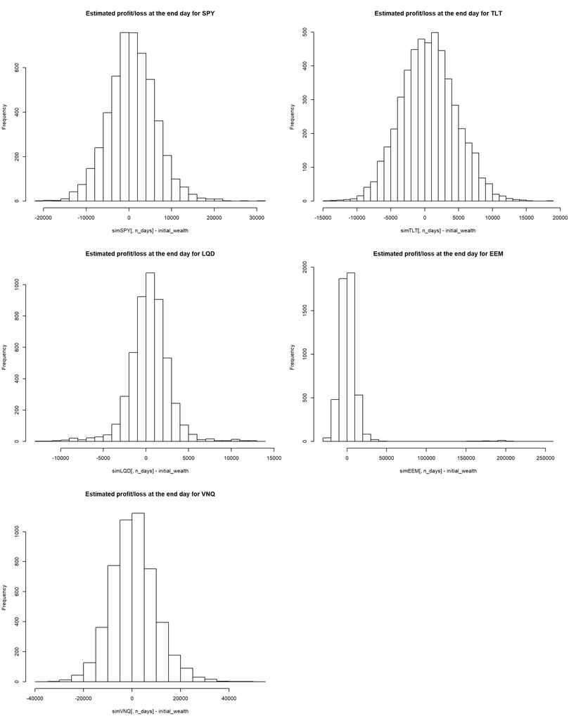

```r
par(mfrow=c(3,2))
hist(simSPY[,n_days]- initial_wealth, breaks=30,main="Estimated profit/loss at the end day for SPY")
hist(simTLT[,n_days]- initial_wealth, breaks=30,main="Estimated profit/loss at the end day for TLT")
hist(simLQD[,n_days]- initial_wealth, breaks=30,main="Estimated profit/loss at the end day for LQD")
hist(simEEM[,n_days]- initial_wealth, breaks=30,main="Estimated profit/loss at the end day for EEM")
hist(simVNQ[,n_days]- initial_wealth, breaks=30,main="Estimated profit/loss at the end day for VNQ")

par(mfrow=c(3,3))
```

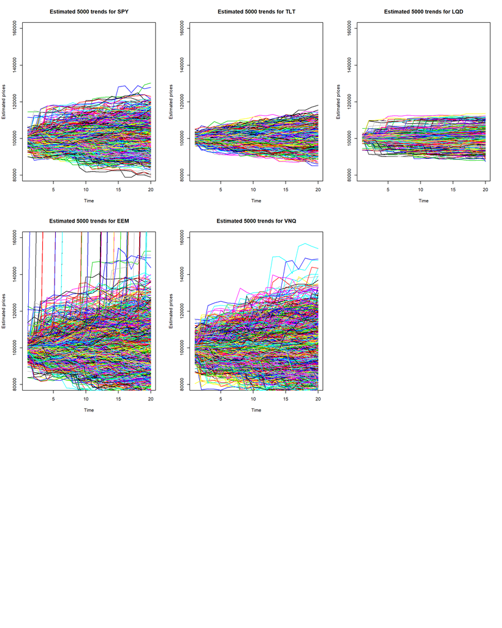

```r
x=1:n_days
plot(x,simSPY[1,],xlab="Time",ylab="Estimated prices",type = "l",ylim=c(80000,160000),main="Estimated 5000 trends for SPY")
for(i in 2:5000){
  lines(x,simSPY[i,],col=i)
}

plot(x,simTLT[1,],xlab="Time",ylab="Estimated prices",type = "l",ylim=c(80000,160000),main="Estimated 5000 trends for TLT")
for(i in 2:5000){
  lines(x,simTLT[i,],col=i)
}

plot(x,simLQD[1,],xlab="Time",ylab="Estimated prices",type = "l",ylim=c(80000,160000),main="Estimated 5000 trends for LQD")
for(i in 2:5000){
  lines(x,simLQD[i,],col=i)
}
plot(x,simEEM[1,],xlab="Time",ylab="Estimated prices",type = "l",ylim=c(80000,160000),main="Estimated 5000 trends for EEM")
for(i in 2:5000){
  lines(x,simEEM[i,],col=i)
}
plot(x,simVNQ[1,],xlab="Time",ylab="Estimated prices",type = "l",ylim=c(80000,160000),main="Estimated 5000 trends for VNQ")
for(i in 2:5000){
  lines(x,simVNQ[i,],col=i)
}
```

## Observing the distribution of estimated prices and potential trends for these five ETFs, we could conclude that the EEM and VNQ are much more risky than other three ETFs. Among these three, LQD is the safest one with the smalleset variance, followed by TLT. And SPY’s variance is the median of these five ETFs.

## The even split

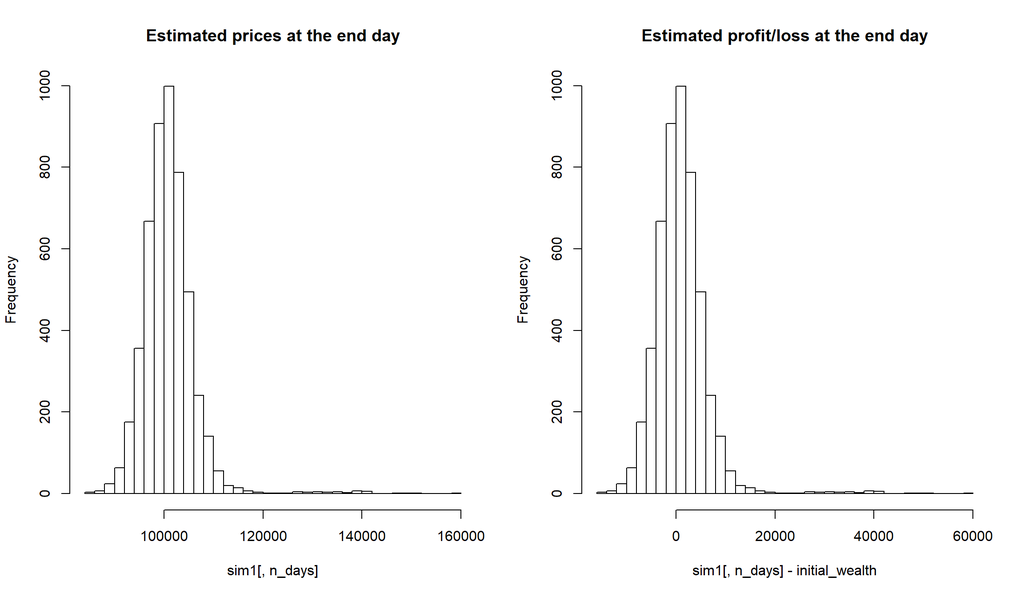

```r
set.seed("666666")

all_returns = cbind(    ClCl(SPYa),
                                ClCl(TLTa),
                                ClCl(LQDa),
                                ClCl(EEMa),
                                ClCl(VNQa))

all_returns = as.matrix(na.omit(all_returns))

initial_wealth = 100000
sim1 = foreach(i=1:5000, .combine='rbind') %do% {
    total_wealth = initial_wealth
    weights = c(0.2, 0.2, 0.2, 0.2, 0.2)
    holdings = weights * total_wealth
    n_days = 20
    wealthtracker = rep(0, n_days)
    for(today in 1:n_days) {
        return.today = resample(all_returns, 1, orig.ids=FALSE)
        holdings = holdings + holdings*return.today
        total_wealth = sum(holdings)
        wealthtracker[today] = total_wealth
    }
    wealthtracker
}

par(mfrow=c(1,2))

hist(sim1[,n_days], 30, main="Estimated prices at the end day")

#profit/loss
hist(sim1[,n_days]- initial_wealth, breaks=30,main="Estimated profit/loss at the end day")
```

```r
# Calculate 5% value at risk
evenmean=mean(sim1[,n_days])
evenVar=quantile(sim1[,n_days], 0.05) - initial_wealth
paste("The 5% value at risk is ",evenVar)
```

```
## [1] "The 5% value at risk is  -6167.09355643528"
```

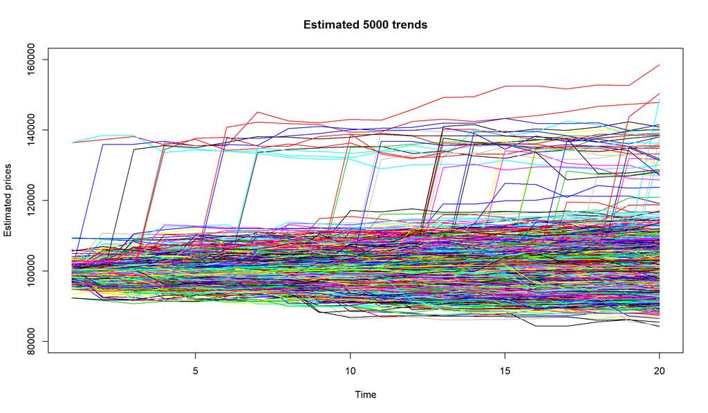

```r
evenprofit = quantile(sim1[,n_days], 0.90) - initial_wealth

par(mfrow=c(1,1))

x=1:n_days
plot(x,sim1[1,],xlab="Time",ylab="Estimated prices",type = "l",ylim=c(80000,160000),main="Estimated 5000 trends")
for(i in 2:5000){
  lines(x,sim1[i,],col=i)
}
```

### From the graphs we can see that the even portfolio’s distribution is similar to the distribution of SPY, the median of these five ETFs. And it has more outliers with high prices, which might be caused by the investment in EEM and VNQ.

## The safer choice

### From the results, we can see that SPY,TLT and LQD, especially LQD, are relatively safer choices. Therefore, we allocate 0.2,0.3,0.5 to SPY,TLT and LQD

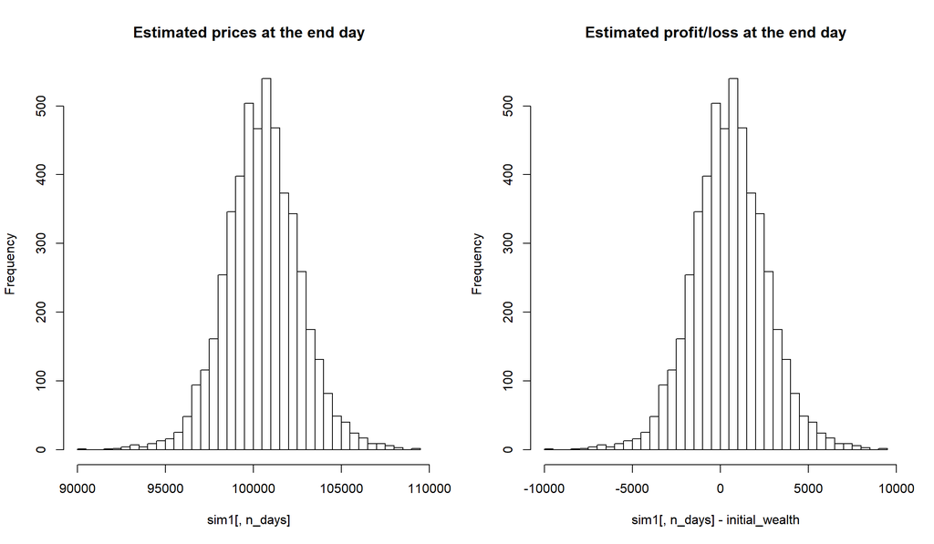

```r
set.seed("666666")

all_returns = cbind(    ClCl(SPYa),
                                ClCl(TLTa),
                                ClCl(LQDa))

all_returns = as.matrix(na.omit(all_returns))

initial_wealth = 100000
sim1 = foreach(i=1:5000, .combine='rbind') %do% {
    total_wealth = initial_wealth
    weights = c(0.2, 0.3, 0.5)
    holdings = weights * total_wealth
    n_days = 20
    wealthtracker = rep(0, n_days)
    for(today in 1:n_days) {
        return.today = resample(all_returns, 1, orig.ids=FALSE)
        holdings = holdings + holdings*return.today
        total_wealth = sum(holdings)
        wealthtracker[today] = total_wealth
    }
    wealthtracker
}

par(mfrow=c(1,2))

hist(sim1[,n_days], 30, main="Estimated prices at the end day")

#profit/loss
hist(sim1[,n_days]- initial_wealth, breaks=30,main="Estimated profit/loss at the end day")
```

```r
# Calculate 5% value at risk
safermean=mean(sim1[,n_days])
saferVar=quantile(sim1[,n_days], 0.05) - initial_wealth
paste("The 5% value at risk is ",saferVar)
```

```
## [1] "The 5% value at risk is  -2870.62687328462"
```

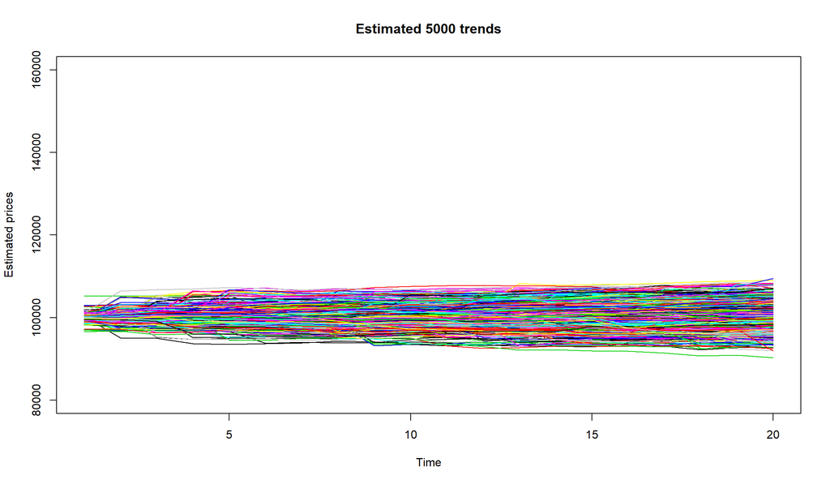

```r
saferprofit = quantile(sim1[,n_days], 0.90) - initial_wealth

par(mfrow=c(1,1))

x=1:n_days
plot(x,sim1[1,],xlab="Time",ylab="Estimated prices",type = "l",ylim=c(80000,160000),main="Estimated 5000 trends")
for(i in 2:5000){
  lines(x,sim1[i,],col=i)
}
```

### From the graphs, we can see the the safer portfolio has much smaller variance even than TLT, just a bit larger than LQD. And it has less outliers with low or high prices than LQD. The probability of significant loss is small but the probability of high return is also small.

## The more aggressive choice

### From the result, we can see that EEM and VNQ are more risky choices, but we still want to keep the SPY to control the risk within acceptable range. Therefore, we allocate 0.4,0.3,0.3 to SPY,EEM and VNQ.

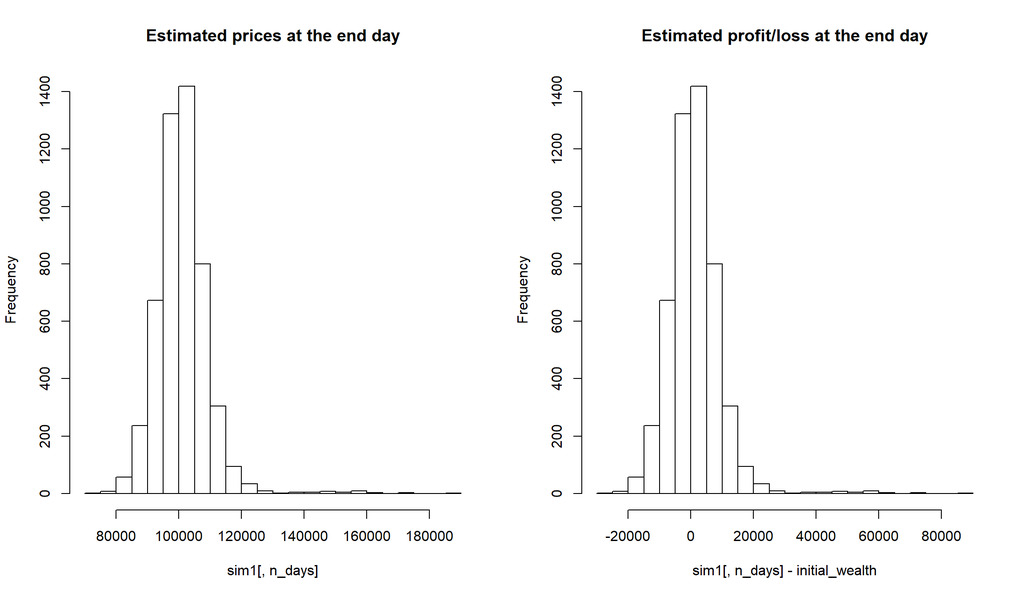

```r
set.seed("666666")

all_returns = cbind(    ClCl(SPYa),
                                ClCl(EEMa),
                                ClCl(VNQa))

all_returns = as.matrix(na.omit(all_returns))

initial_wealth = 100000
sim1 = foreach(i=1:5000, .combine='rbind') %do% {
    total_wealth = initial_wealth
    weights = c(0.4,0.3,0.3)
    holdings = weights * total_wealth
    n_days = 20
    wealthtracker = rep(0, n_days)
    for(today in 1:n_days) {
        return.today = resample(all_returns, 1, orig.ids=FALSE)
        holdings = holdings + holdings*return.today
        total_wealth = sum(holdings)
        wealthtracker[today] = total_wealth
    }
    wealthtracker
}

par(mfrow=c(1,2))

hist(sim1[,n_days], 30, main="Estimated prices at the end day")

#profit/loss
hist(sim1[,n_days]- initial_wealth, breaks=30,main="Estimated profit/loss at the end day")
```

```r
# Calculate 5% value at risk
aggmean=mean(sim1[,n_days])
aggVar=quantile(sim1[,n_days], 0.05) - initial_wealth
paste("The 5% value at risk is ",aggVar)
```

```
## [1] "The 5% value at risk is  -10690.186019198"
```

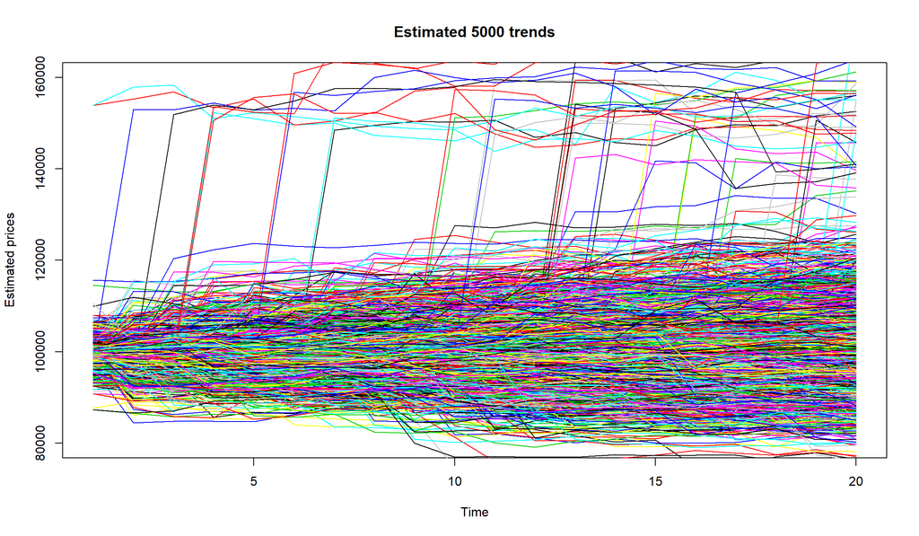

```r
aggprofit = quantile(sim1[,n_days], 0.90) - initial_wealth

par(mfrow=c(1,1))

x=1:n_days
plot(x,sim1[1,],xlab="Time",ylab="Estimated prices",type = "l",ylim=c(80000,160000),main="Estimated 5000 trends")
for(i in 2:5000){
  lines(x,sim1[i,],col=i)
}
```

### From the graphs, we can see that this portfolio has much larger variance.It has chance to gain significant high return, but it is also more risky than other portfolios.

## Comparison of all portfolios for decision making

```r
t <- matrix(c(SPYVar,SPYmean,SPYprofit,TLTVar,TLTmean,TLTprofit,LQDVar,LQDmean,LQDprofit,EEMVar,EEMmean,EEMprofit,VNQVar,VNQmean,VNQprofit,evenVar,evenmean,evenprofit,saferVar,safermean,saferprofit,aggVar,aggmean,aggprofit),ncol=3,byrow=TRUE)
colnames(t) <- c("5% Value at Risk","Expected return","The top 10% potential profit")
rownames(t) <- c("SPY","TLT","LQD","EEM","VNQ","Even","Safer","Aggressive")
t <- as.table(t)
t
```

```
##            5% Value at Risk Expected return The top 10% potential profit
## SPY               -8388.289      100759.214                     7527.351
## TLT               -5999.653      100597.012                     5939.240
## LQD               -3028.365      100392.989                     2872.259
## EEM              -13558.980      102036.121                    11992.560
## VNQ              -13742.735      100738.234                    12244.381
## Even              -6167.094      100904.714                     6097.981
## Safer             -2870.627      100527.441                     3113.661
## Aggressive       -10690.186      101135.992                     9824.144
```